# Experiment 1 Analysis

Bonan Zhao

10/31/2021

# Experiment

## Materials

In this experiment we have:

- Agent object properties: number of stripes and dots (randomly positioned).
- Recipient object properties: number of blocks.
- Result object properties: number of blocks.
- Animation: an agent object moves towards a recipient object, and the recipient object changes into the result form by varying its original number of blocks.
- **Ground-truth** rule is a mixture of multiplication and subtraction: `Blocks(R') <- Stripes(A) * Blocks(R) - Dots(A)`.

And three **learning conditions**:

1. `Construct`: First build the `Stripes(A) * Blocks(R)` sub-part, and then re-use it to build the ground truth rule

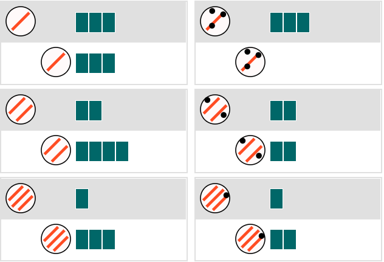

2. `Deconstruct`: reverse order of the `construct` condition

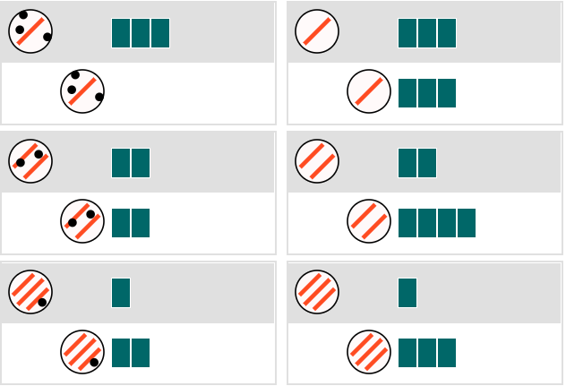

3. `Combine`: First build the `Stripes(A) * Blocks(R)` sub-part, and then build the `- Dots(A)` sub-part

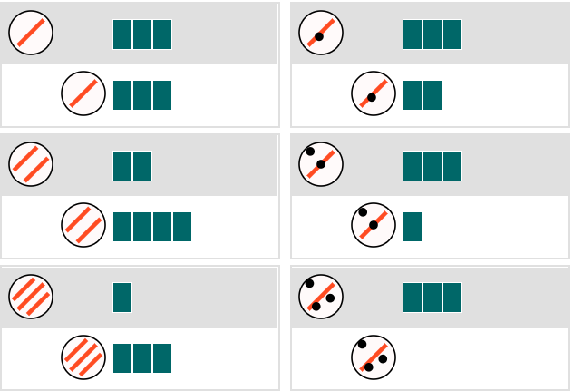

**Generalization trials** are picked by a mixture of novelty & EIG re. potential causal rules. Their orders were randomized for every participant.

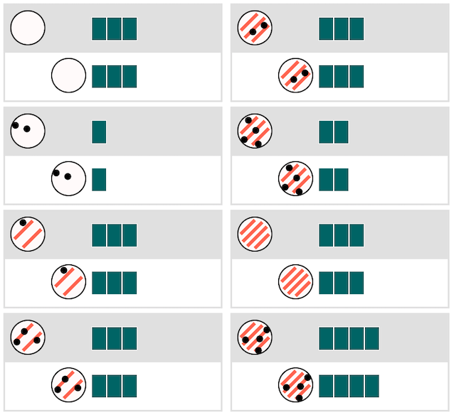

## Procedure

Each participant is randomly assigned to one of the three learning conditions. After reading instructions and passing a comprehension quiz, they first watched three learning examples, and then were asked to write down their guesses about the underlying causal relationships & made generalization predictions for eight pairs of novel objects. After that, they watched another three learning examples, and then wrote down an updated guess and made 8 generalization predictions. The pairs of generalization objects in both phases are the same, but their presentation orders were randomized. All learning examples were remained in the screen once they had appeared. Generalization trials appeared sequentially, and once a prediction was made the trial was replaced by the next one.

Pre-registration: https://osf.io/ud7jc

# Pilot results

Recruited N = 165 participants on Prolific (age = 32 ± 9.9).

Mean time spent 14.15 minutes.

Base payment is £1.25, and bonus are paid for both free-responses (£0.20 per input, 2 inputs in total) and generalization predictions (£0.02 per correct one with respect to ground-truth).

Overview (cells are mean values, time in minutes, difficulty & engagement scales are 1-10)

| condition | n | age | intro_time | task_time | difficulty | engagement |
| --- | --- | --- | --- | --- | --- | --- |
| combine | 54 | 32 | 4.51 | 9.04 | 6.35 | 8.80 |
| construct | 56 | 32 | 3.95 | 8.81 | 6.39 | 8.68 |
| decon | 55 | 31 | 4.91 | 11.24 | 7.82 | 8.38 |

## Task difficulty

Participants in the `deconstruct` condition took the longest time to finish the task, and reported the highest self-evaluated difficulty as well. Participants in the other two conditions, where sub-parts were built before seeing complex examples, took less time to finish the task and reported lower difficulty evaluations.

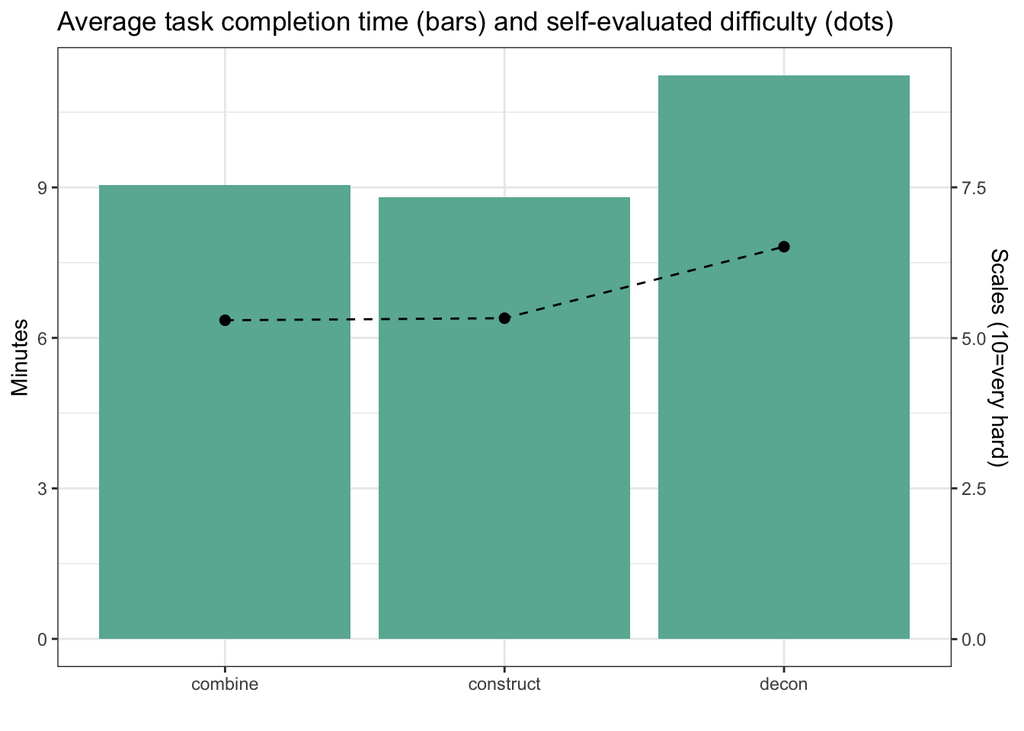

## Accuracy

For generalization predictions, participants in the “deconstruct” condition have lowest accuracy after both Phase A and Phase B learning. Participants in all three conditions have low generalization prediction accuracy after Phase A - their prior belief about dot feature’s causal power must differ from our setup

For self-reports, participants in the “deconstruct” condition fail catastrophically after Phase A, and then improve a lot after Phase B, but still lower than the other two conditions’ Phase A accuracy level.

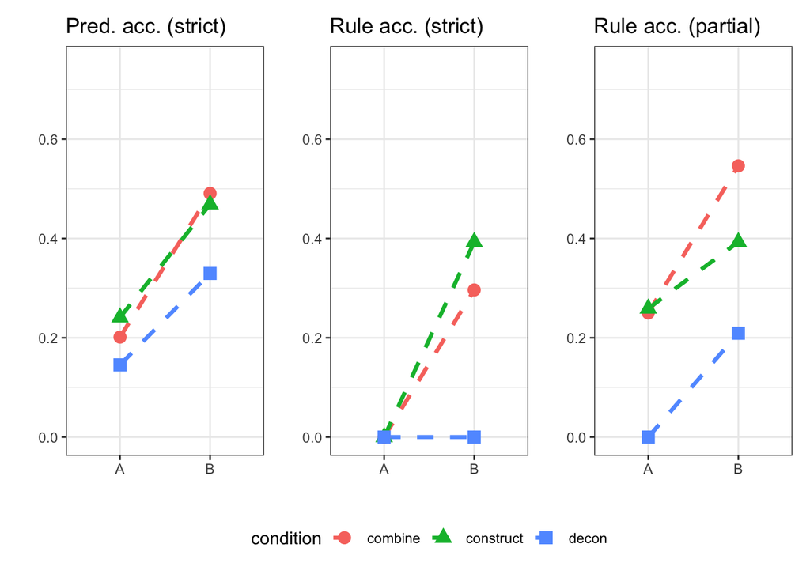

After Phase A, participants in the “combine” and “construct” conditions seem to apply the multiplication rule in generalization - but not always.

## Self-reports

Participants in the “deconstruct” condition have lowest self-report certainty, and they also tried to write more elaborated guesses. Overall it looks like a negative relationship between certainty and input length.

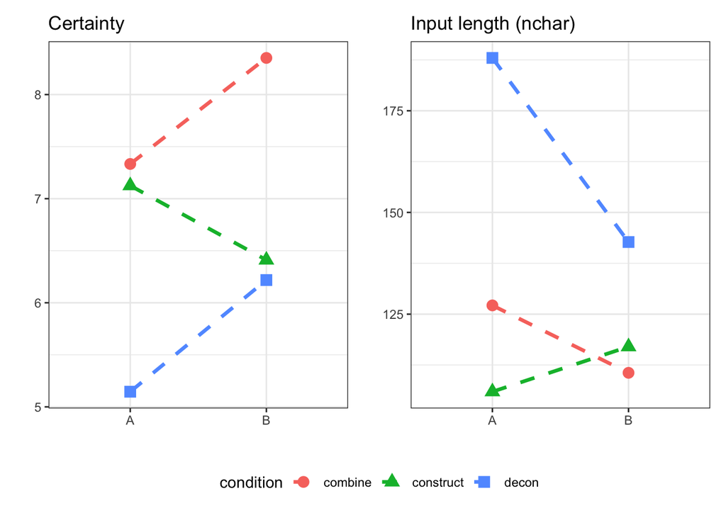

## Labels

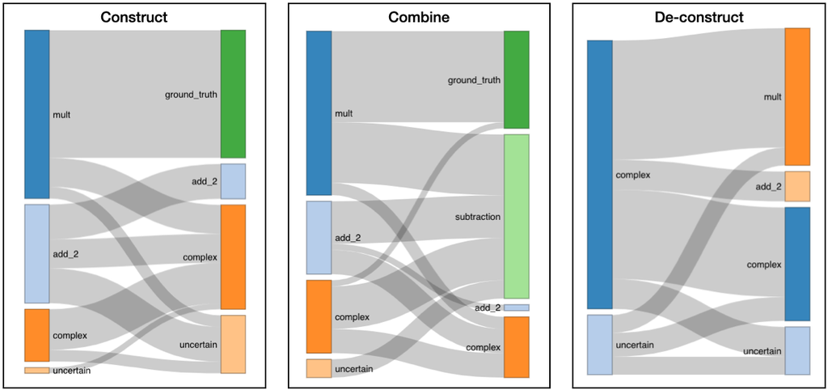

# Model preds

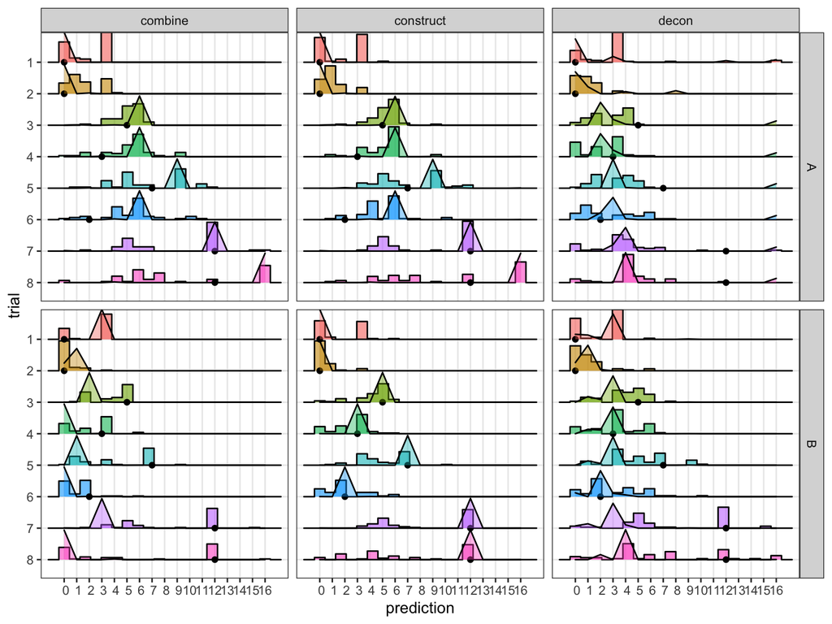